# Caso práctico 4: Generación de mapas de precipitación mediante técnicas de krigeado

Análisis descriptivo y regresión lineal

#### Install packages.

```r
# install.packages("maptools")
# install.packages("rgdal")
# install.packages("raster")
# install.packages("classInt")
# install.packages("RColorBrewer")
```

#### Load packages.

```r
library(maptools)
library(rgdal)
library(raster)
library(classInt)
library(RColorBrewer)
library(latex2exp)
```

#### Set working directory

Note that in R the bar of a path is / while in Windows it is the counterbar.

```r
setwd("../caso_practico_4/")
```

#### Loading and ploting the observations

Fisrt we can have a look to the help page of the function for loading a shape point file.

```r
# help(readShapePoints)
```

Reading the shape point file which contains the data and converting it to a spatial-points object of R.

```r
dat <- readShapePoints("Datos_cp4/precip_seasonal.shp")
```

A summary of the structure and content of the created object

```r
str(dat)
```

```
## Formal class 'SpatialPointsDataFrame' [package "sp"] with 5 slots
##   ..@ data       :'data.frame':  212 obs. of  16 variables:
##   .. ..$ INDICATIU : Factor w/ 212 levels "E7029","E7031",..: 1 2 3 4 5 6 7 8 9 10 ...
##   .. ..$ ESTACIO   : Factor w/ 212 levels "AGOST  ESCUELA NACIONAL",..: 173 125 143 109 20 108 93 101 163 80 ...
##   .. ..$ ALTITUD   : int [1:212] 203 2 45 1 40 2 60 502 36 90 ...
##   .. ..$ X         : num [1:212] 680954 693537 695385 701067 695181 ...
##   .. ..$ Y         : num [1:212] 4195707 4184490 4195298 4205830 4211023 ...
##   .. ..$ PROVINCIA : Factor w/ 8 levels "ALBACETE","ALICANTE",..: 5 5 2 2 2 2 2 5 5 5 ...
##   .. ..$ MesosCompl: int [1:212] 549 552 343 552 401 550 402 451 551 477 ...
##   .. ..$ MesosNoCom: int [1:212] 3 0 209 0 151 2 150 101 1 75 ...
##   .. ..$ AnysComple: int [1:212] 43 46 22 46 31 44 28 35 45 36 ...
##   .. ..$ AnysIncomp: int [1:212] 3 0 9 0 4 2 7 3 1 6 ...
##   .. ..$ AnysBuits : int [1:212] 0 0 15 0 11 0 11 8 0 4 ...
##   .. ..$ spring    : num [1:212] 78.9 76.5 74.7 61.9 80 ...
##   .. ..$ summer    : num [1:212] 25 23.8 20.6 17.7 19.8 ...
##   .. ..$ autumn    : num [1:212] 99.6 119.7 109.3 101.6 116.7 ...
##   .. ..$ winter    : num [1:212] 83.6 93.9 89.9 75.4 85 ...
##   .. ..$ annual    : num [1:212] 287 314 295 257 301 ...
##   .. ..- attr(*, "data_types")= chr [1:16] "C" "C" "N" "F" ...
##   ..@ coords.nrs : num(0)
##   ..@ coords     : num [1:212, 1:2] 680954 693537 695385 701067 695181 ...
##   .. ..- attr(*, "dimnames")=List of 2
##   .. .. ..$ : chr [1:212] "0" "1" "2" "3" ...
##   .. .. ..$ : chr [1:2] "coords.x1" "coords.x2"
##   ..@ bbox       : num [1:2, 1:2] 603884 4184490 814056 4532311
##   .. ..- attr(*, "dimnames")=List of 2
##   .. .. ..$ : chr [1:2] "coords.x1" "coords.x2"
##   .. .. ..$ : chr [1:2] "min" "max"
##   ..@ proj4string:Formal class 'CRS' [package "sp"] with 1 slot
##   .. .. ..@ projargs: chr NA
```

```r
dev.new()
plot(dat)
```

[output not shown]

#### Loading and ploting the observations the Valencian Community (VC) administrative boundaries

Reading the shape polygons file which contains the border of the Valencian Community and converting it to a spatial-polygons object of R.

Visualizing a summary of the structure and content of the object.

Plot the border map.

```r
lim_cv <- readShapePoly("Datos_cp4/cv.shp")
str(lim_cv)
```

```
## Formal class 'SpatialPolygonsDataFrame' [package "sp"] with 5 slots
##   ..@ data       :'data.frame':  1 obs. of  1 variable:
##   .. ..$ PROVIN_ID: int 1
##   .. ..- attr(*, "data_types")= chr "N"
##   ..@ polygons   :List of 1
##   .. ..$ :Formal class 'Polygons' [package "sp"] with 5 slots
##   .. .. .. ..@ Polygons :List of 2
##   .. .. .. .. ..$ :Formal class 'Polygon' [package "sp"] with 5 slots
##   .. .. .. .. .. .. ..@ labpt  : num [1:2] 647997 4437991
##   .. .. .. .. .. .. ..@ area   : num 3.7e+08
##   .. .. .. .. .. .. ..@ hole   : logi FALSE
##   .. .. .. .. .. .. ..@ ringDir: int 1
##   .. .. .. .. .. .. ..@ coords : num [1:201, 1:2] 647805 648974 649215 649557 649612 ...
##   .. .. .. .. ..$ :Formal class 'Polygon' [package "sp"] with 5 slots
##   .. .. .. .. .. .. ..@ labpt  : num [1:2] 711404 4362427
##   .. .. .. .. .. .. ..@ area   : num 2.29e+10
##   .. .. .. .. .. .. ..@ hole   : logi FALSE
##   .. .. .. .. .. .. ..@ ringDir: int 1
##   .. .. .. .. .. .. ..@ coords : num [1:3291, 1:2] 741050 740996 740864 740933 741112 ...
##   .. .. .. ..@ plotOrder: int [1:2] 2 1
##   .. .. .. ..@ labpt    : num [1:2] 711404 4362427
##   .. .. .. ..@ ID       : chr "0"
##   .. .. .. ..@ area     : num 2.33e+10
##   ..@ plotOrder  : int 1
##   ..@ bbox       : num [1:2, 1:2] 626680 4191040 797835 4519371
##   .. ..- attr(*, "dimnames")=List of 2
##   .. .. ..$ : chr [1:2] "x" "y"
##   .. .. ..$ : chr [1:2] "min" "max"
##   ..@ proj4string:Formal class 'CRS' [package "sp"] with 1 slot
##   .. .. ..@ projargs: chr NA
```

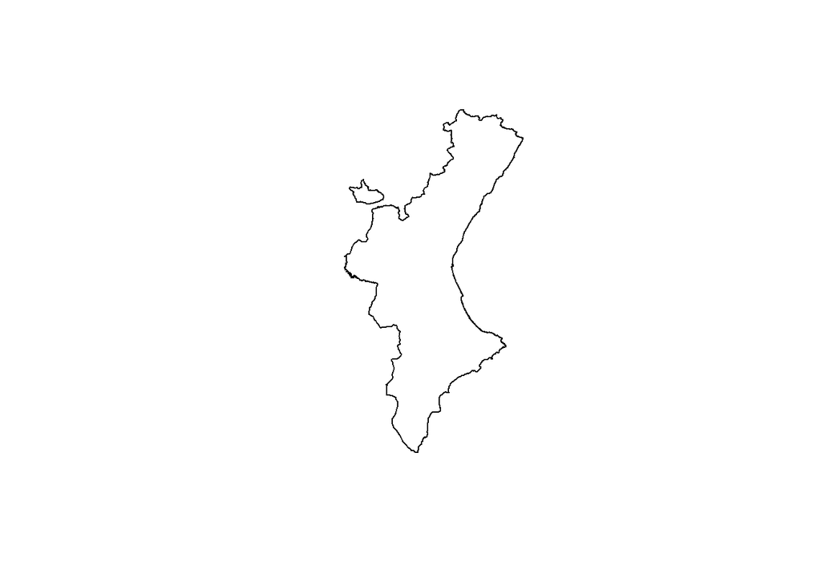

```r
plot(lim_cv)
```

#### Loading and ploting the the raster file with the Digital Elevation Model (DEM)

Reading the raster file which contains DEM and converting it to a raster object of R.

Visualizing a summary of the structure and content of the object.

Plot the DEM map.

```r
ras <- raster("Datos_cp4/mde_100.tif", layer=0, values=TRUE)
str(ras)
```

```
## Formal class 'RasterLayer' [package "raster"] with 12 slots
##   ..@ file    :Formal class '.RasterFile' [package "raster"] with 13 slots
##   .. .. ..@ name        : chr "C:\\GABRIEL_20192301\\DOCTORADO\\Asignaturas-docencia\\GEOESTADISTICA\\Datos_cp4\\mde_100.tif"
##   .. .. ..@ datanotation: chr "FLT4S"
##   .. .. ..@ byteorder   : chr "little"
##   .. .. ..@ nodatavalue : num -Inf
##   .. .. ..@ NAchanged   : logi FALSE
##   .. .. ..@ nbands      : int 1
##   .. .. ..@ bandorder   : chr "BIL"
##   .. .. ..@ offset      : int 0
##   .. .. ..@ toptobottom : logi TRUE
##   .. .. ..@ blockrows   : int 128
##   .. .. ..@ blockcols   : int 128
##   .. .. ..@ driver      : chr "gdal"
##   .. .. ..@ open        : logi FALSE
##   ..@ data    :Formal class '.SingleLayerData' [package "raster"] with 13 slots
##   .. .. ..@ values    : logi(0)
##   .. .. ..@ offset    : num 0
##   .. .. ..@ gain      : num 1
##   .. .. ..@ inmemory  : logi FALSE
##   .. .. ..@ fromdisk  : logi TRUE
##   .. .. ..@ isfactor  : logi FALSE
##   .. .. ..@ attributes: list()
##   .. .. ..@ haveminmax: logi FALSE
##   .. .. ..@ min       : num Inf
##   .. .. ..@ max       : num -Inf
##   .. .. ..@ band      : int 1
##   .. .. ..@ unit      : chr ""
##   .. .. ..@ names     : chr "mde_100"
##   ..@ legend  :Formal class '.RasterLegend' [package "raster"] with 5 slots
##   .. .. ..@ type      : chr(0)
##   .. .. ..@ values    : logi(0)
##   .. .. ..@ color     : logi(0)
##   .. .. ..@ names     : logi(0)
##   .. .. ..@ colortable: logi(0)
##   ..@ title   : chr(0)
##   ..@ extent  :Formal class 'Extent' [package "raster"] with 4 slots
##   .. .. ..@ xmin: num 6e+05
##   .. .. ..@ xmax: num 839939
##   .. .. ..@ ymin: num 4149746
##   .. .. ..@ ymax: num 4549946
##   ..@ rotated : logi FALSE
##   ..@ rotation:Formal class '.Rotation' [package "raster"] with 2 slots
##   .. .. ..@ geotrans: num(0)
##   .. .. ..@ transfun:function ()
##   ..@ ncols   : int 2403
##   ..@ nrows   : int 4002
##   ..@ crs     :Formal class 'CRS' [package "sp"] with 1 slot
##   .. .. ..@ projargs: chr "+proj=utm +zone=30 +ellps=GRS80 +units=m +no_defs"
##   ..@ history : list()
##   ..@ z       : list()
```

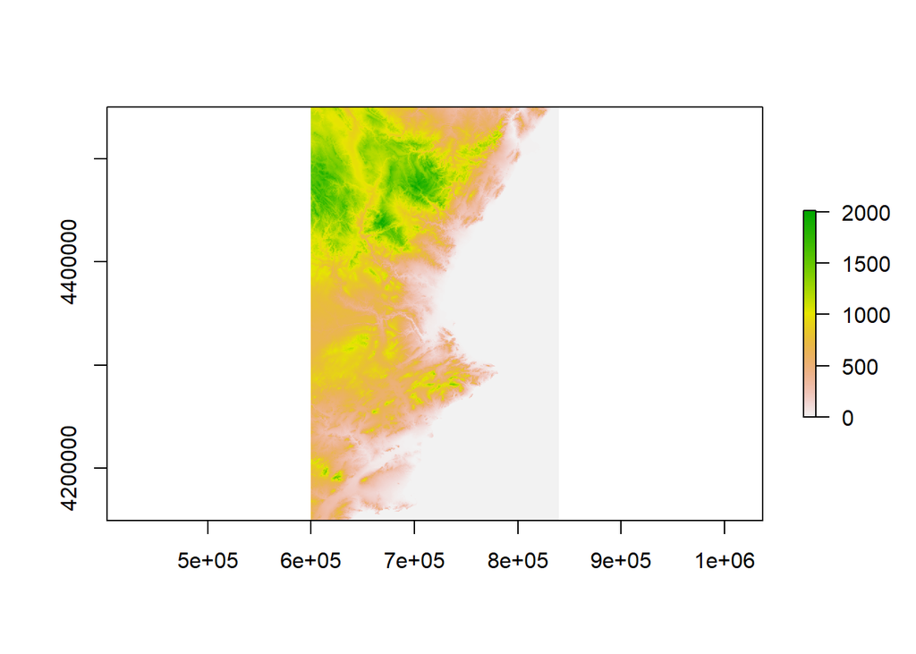

```r
plot(ras)
```

#### Plot of the observations and the DEM

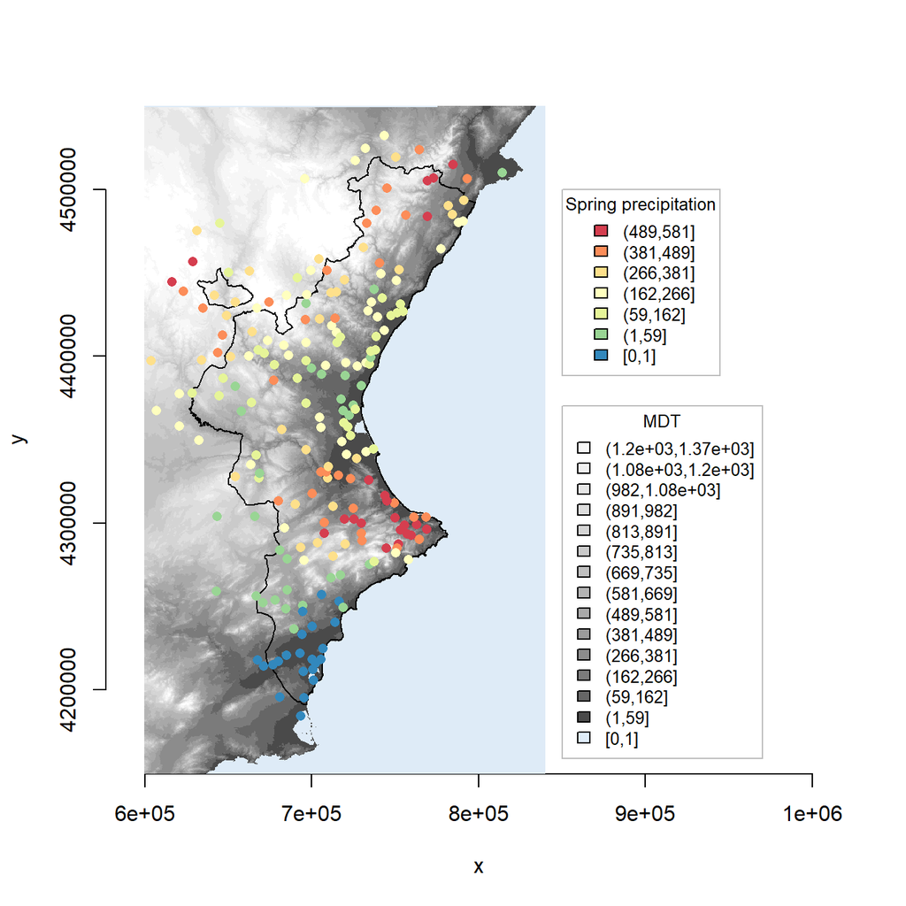

```r
# ploting the DEM
q1 <- classIntervals(getValues(ras)[getValues(ras)>0.05], n = 15, style = "quantile")
q1$brks <- round(c(0,q1$brks),1)
col <- c("#deebf7", gray.colors(16, start = 0.0, end = 1, alpha = 1)[-1])
image(ras, col=col, breaks=q1$brks, asp=1, frame.plot = FALSE, xlim=c(600000,1000000))

# adding the DEM's legend
br <- cut(getValues(ras), breaks=q1$brks, include.lowest=TRUE)
legend(x=850000, y=4370000, legend=levels(br)[15:1], fill=col[15:1], ncol=1, title= "MDT", cex=0.8, box.col = "grey")

# adding the borders of VC.
lines(lim_cv, col="black", lwd=1)

# adding the observations
q <- quantile(dat@data$spring, c(0,0.10,0.25,0.40,0.60,0.75,0.90,1))
br1 <- cut(dat@data$spring, breaks=q, include.lowest=TRUE)
points(dat@coords[,1:2], col=brewer.pal(7,"Spectral")[7:1][br1], asp=1, pch=16)

# adding a legend fot the observations
legend(x=850000, y=4500000, legend=levels(br)[7:1], fill=brewer.pal(7,"Spectral")[1:7], title= "Spring precipitation", cex=0.8, box.col = "grey")
```

#### Frecuency histograms of the precipitation variables.

Frecuency histograms and standard deviation of the precipitation variables: ‘annual’, ‘spring’, ‘summer’, ‘autumn’ and ‘winter’.

```r
par(mfrow=c(2,3))

hist(dat@data$annual, breaks=20, main="annual"); print("sd annual"); sd(dat@data$annual)
```

```
## [1] "sd annual"
```

```
## [1] 133.1659
```

```r
hist(dat@data$spring, breaks=20, main="spring"); print("sd spring"); sd(dat@data$spring)
```

```
## [1] "sd spring"
```

```
## [1] 32.77024
```

```r
hist(dat@data$summer, breaks=20, main="summer"); print("sd summer"); sd(dat@data$summer)
```

```
## [1] "sd summer"
```

```
## [1] 26.5116
```

```r
hist(dat@data$autumn, breaks=20, main="autumn"); print("sd autumn"); sd(dat@data$autumn)
```

```
## [1] "sd autumn"
```

```
## [1] 51.39329
```

```
## [1] "sd winter"
```

```
## [1] 46.03267
```

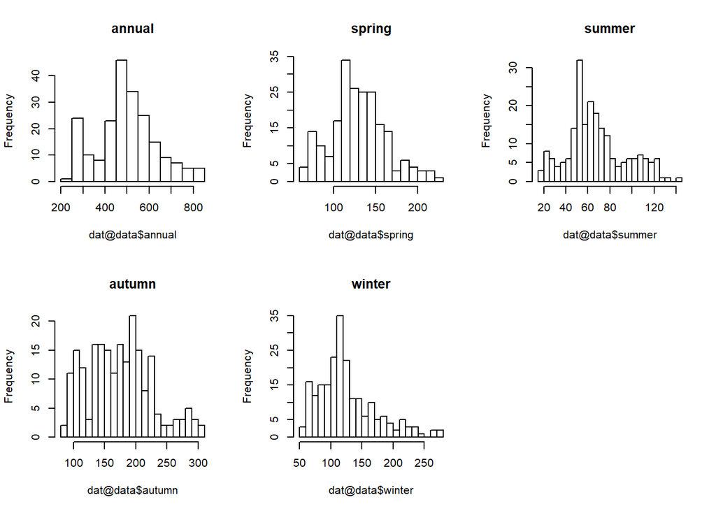

```r
hist(dat@data$winter, breaks=20, main="winter"); print("sd winter"); sd(dat@data$winter)
```

#### Frecuency histograms of co-variables.

Frecuency histograms of the variables: ‘ALTITUD’, ‘Xutm’, ‘Yutm’.

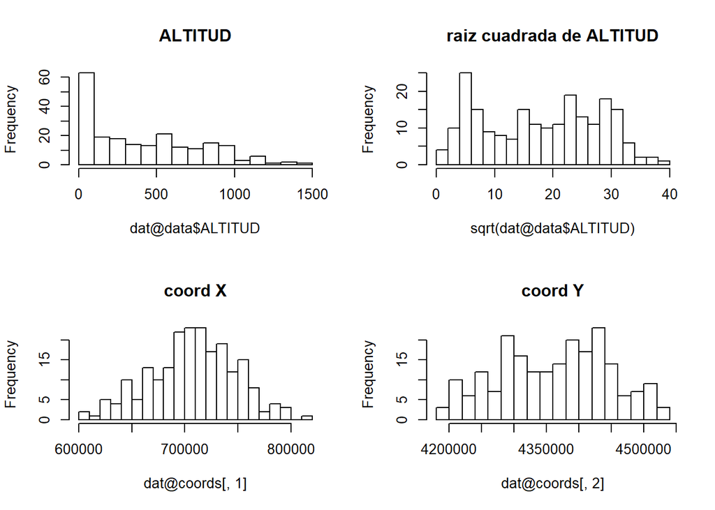

```r
par(mfrow=c(2,2))

hist(dat@data$ALTITUD, breaks=20, main="ALTITUD")
hist(sqrt(dat@data$ALTITUD), breaks=20, main="raiz cuadrada de ALTITUD")
hist(dat@coords[,1], breaks=20, main="coord X")
hist(dat@coords[,2], breaks=20, main="coord Y")
```

### LINEAR REGRESION MODELS

#### *Model 1*:

$$\begin{align}
& X^{spring}_i \sim \mathcal{N}(\mu_i,\sigma^2), \hspace{15mm} i=1,\cdots,n \\
\\
&\mu_i = \beta_0 + \beta_1 X^{altitud}_i
\end{align}$$

Model adjustment.

```r
aj_1 <- lm( spring ~ ALTITUD, data=dat@data )
summary(aj_1)
```

```
##
## Call:
## lm(formula = spring ~ ALTITUD, data = dat@data)
##
## Residuals:
##     Min      1Q  Median      3Q     Max
## -58.571 -19.813  -2.976  14.107  90.742
##
## Coefficients:
##              Estimate Std. Error t value Pr(>|t|)
## (Intercept) 1.193e+02  3.308e+00  36.062  < 2e-16 ***
## ALTITUD     2.432e-02  5.964e-03   4.078 6.45e-05 ***
## ---
## Signif. codes:  0 '***' 0.001 '**' 0.01 '*' 0.05 '.' 0.1 ' ' 1
##
## Residual standard error: 31.62 on 210 degrees of freedom
## Multiple R-squared:  0.07338,    Adjusted R-squared:  0.06896
## F-statistic: 16.63 on 1 and 210 DF,  p-value: 6.45e-05
```

Diagnosis plots.

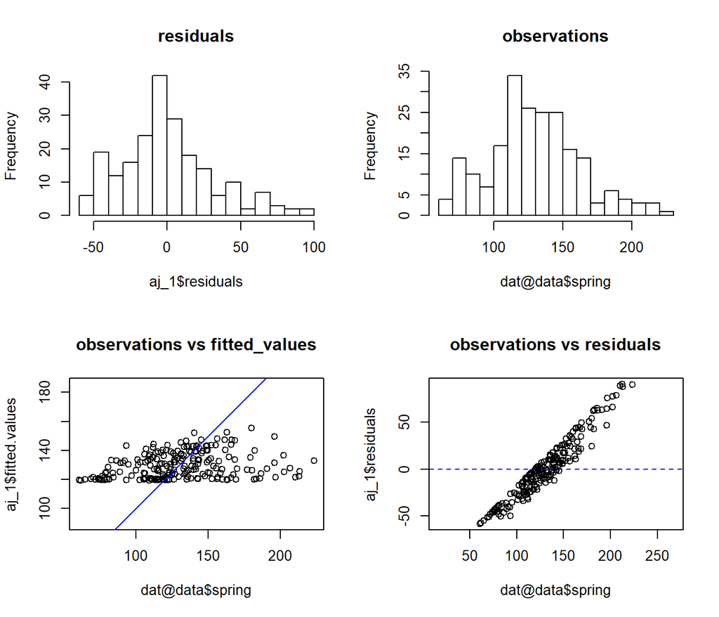

```r
par(mfrow=c(2,2))

hist(aj_1$residuals, breaks=20, main="residuals")   # Histogram of the fitted residuals
hist(dat@data$spring, breaks=20, main="observations")   # Histogram of the variable 'spring'

# Plot observations vs fitted values
plot(dat@data$spring, aj_1$fitted.values, asp=1, main="observations vs fitted_values")
abline(a=0, b=1, col="blue", lty=1, lwd=1)

# Plot observations vs residuals
plot(dat@data$spring, aj_1$residuals, asp=1, main="observations vs residuals")
abline(h=0, col="blue", lty=2)
```

#### *Model 2*:

$$\begin{align}
& X^{spring}_i \sim \mathcal{N}(\mu_i,\sigma^2), \hspace{15mm} i=1,\cdots,n \\
\\
&\mu_i = \beta_0 + \beta_1 \cdot X^{Xutm}_i + \beta_2 \cdot X^{Yutm}_i + \beta_3 \cdot X^{Xutm}_i \cdot X^{Yutm}_i.
\end{align}$$

Model adjustment.

Diagnosis plots.

```r
aj_2 <- lm( spring ~ dat@coords[,1]*dat@coords[,2], data=dat@data )
summary(aj_2)
```

```
##
## Call:
## lm(formula = spring ~ dat@coords[, 1] * dat@coords[, 2], data = dat@data)
##
## Residuals:
##    Min     1Q Median     3Q    Max
## -48.67 -19.69  -4.19  18.82  74.95
##
## Coefficients:
##                                   Estimate Std. Error t value Pr(>|t|)
## (Intercept)                     -1.340e+04  1.881e+03  -7.126 1.67e-11 ***
## dat@coords[, 1]                  1.820e-02  2.635e-03   6.908 5.89e-11 ***
## dat@coords[, 2]                  3.051e-03  4.277e-04   7.134 1.59e-11 ***
## dat@coords[, 1]:dat@coords[, 2] -4.099e-09  5.987e-10  -6.845 8.42e-11 ***
## ---
## Signif. codes:  0 '***' 0.001 '**' 0.01 '*' 0.05 '.' 0.1 ' ' 1
##
## Residual standard error: 27.08 on 208 degrees of freedom
## Multiple R-squared:  0.3271, Adjusted R-squared:  0.3174
## F-statistic:  33.7 on 3 and 208 DF,  p-value: < 2.2e-16
```

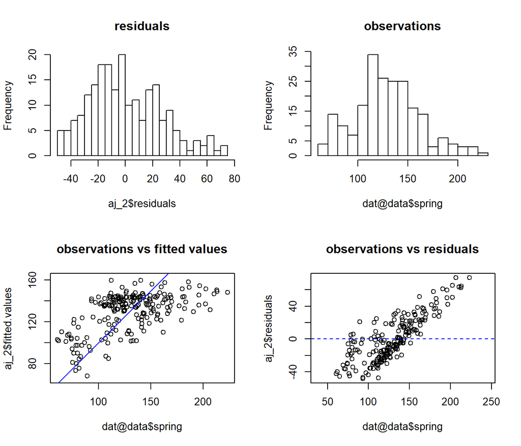

```r
par(mfrow=c(2,2))

hist(aj_2$residuals, breaks=20, main="residuals")   # Histogram of the fitted residuals
hist(dat@data$spring, breaks=20, main="observations")   # Histogram of the variable 'spring'

# Plot observations vs fitted values
plot(dat@data$spring, aj_2$fitted.values, asp=1, main="observations vs fitted values")
abline(a=0, b=1, col="blue", lty=1, lwd=1)

# Plot observations vs residuals
plot(dat@data$spring, aj_2$residuals, asp=1, main="observations vs residuals")
abline(h=0, col="blue", lty=2)
```

#### Vizualizing the Meaning of the linear model effects

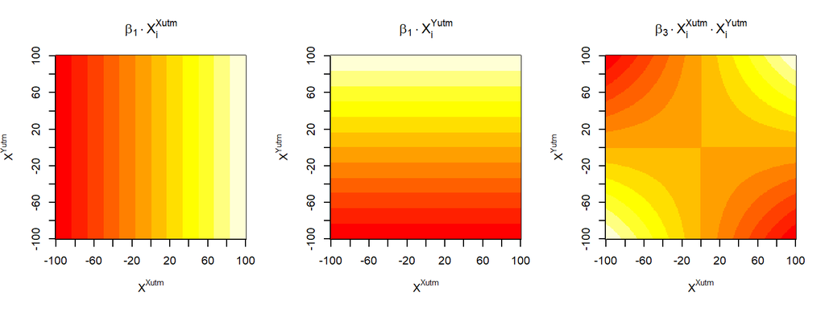

```r
x <- rep(-100:100,201)
y <- rep(-100:100,each=201)
grd <- cbind(x,y)
z_xy <- apply(grd, 1, prod)

par(mfrow=c(1,3))

image(1:201,1:201,matrix(grd[,1],201,201),ann=FALSE,xaxt="n",yaxt="n")
axis(1, at = seq(1,201,20), labels = seq(-100,100,20))
axis(2, at = seq(1,201,20), labels = seq(-100,100,20))
title(main=TeX('$\\beta_1 \\cdot X^{Xutm}_i$'),  xlab =TeX('$X^{Xutm}$'), ylab =TeX('$X^{Yutm}$'), las=1)

image(1:201,1:201,matrix(grd[,2],201),ann=FALSE,xaxt="n",yaxt="n")
axis(1, at = seq(1,201,20), labels = seq(-100,100,20))
axis(2, at = seq(1,201,20), labels = seq(-100,100,20))
title(main=TeX('$\\beta_1 \\cdot X^{Yutm}_i$'),  xlab =TeX('$X^{Xutm}$'), ylab =TeX('$X^{Yutm}$'), las=1)

image(1:201,1:201,matrix(z_xy,201,201),ann=FALSE,xaxt="n",yaxt="n", xlab="X1")
axis(1, at = seq(1,201,20), labels = seq(-100,100,20))
axis(2, at = seq(1,201,20), labels = seq(-100,100,20))
title(main=TeX('$\\beta_3 \\cdot X^{Xutm}_i \\cdot X^{Yutm}_i$'),  xlab =TeX('$X^{Xutm}$'), ylab =TeX('$X^{Yutm}$'), las=1)
```

#### *Model 3*:

$$\begin{align}
& X^{spring}_i \sim \mathcal{N}(\mu_i,\sigma^2), \hspace{15mm} i=1,\cdots,n \\
\\
&\mu_i = \beta_0 + \beta_1 \cdot X^{altitud}_i + \beta_2 \cdot X^{Xutm}_i + \beta_3 \cdot X^{Yutm}_i + \beta_4 \cdot X^{Xutm}_i \cdot X^{Yutm}_i.
\end{align}$$

Model adjustment.

Diagnosis plots.

```r
aj_3 <- lm( spring ~ ALTITUD + dat@coords[,1]*dat@coords[,2] , data=dat@data )
summary(aj_3)
```

```
##
## Call:
## lm(formula = spring ~ ALTITUD + dat@coords[, 1] * dat@coords[,
##     2], data = dat@data)
##
## Residuals:
##     Min      1Q  Median      3Q     Max
## -64.743 -15.283  -2.497  14.037  68.117
##
## Coefficients:
##                                   Estimate Std. Error t value Pr(>|t|)
## (Intercept)                     -1.137e+04  1.733e+03  -6.560 4.22e-10 ***
## ALTITUD                          4.852e-02  7.186e-03   6.751 1.45e-10 ***
## dat@coords[, 1]                  1.596e-02  2.414e-03   6.612 3.16e-10 ***
## dat@coords[, 2]                  2.537e-03  3.955e-04   6.414 9.44e-10 ***
## dat@coords[, 1]:dat@coords[, 2] -3.524e-09  5.500e-10  -6.408 9.80e-10 ***
## ---
## Signif. codes:  0 '***' 0.001 '**' 0.01 '*' 0.05 '.' 0.1 ' ' 1
##
## Residual standard error: 24.57 on 207 degrees of freedom
## Multiple R-squared:  0.4485, Adjusted R-squared:  0.4379
## F-statistic: 42.09 on 4 and 207 DF,  p-value: < 2.2e-16
```

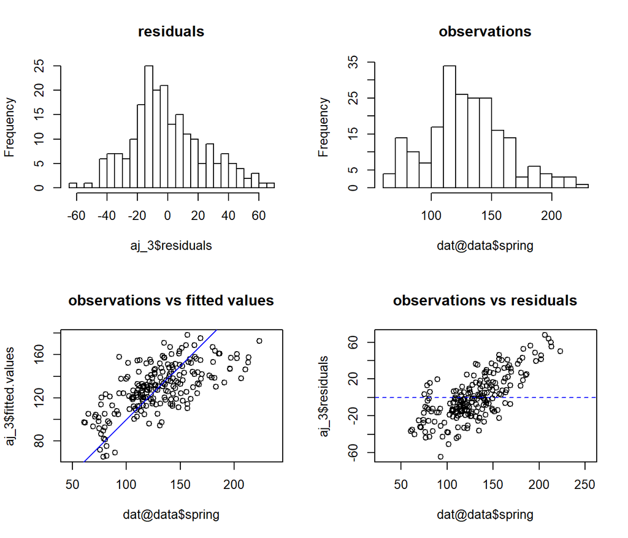

```r
par(mfrow=c(2,2))

hist(aj_3$residuals, breaks=20, main="residuals")   # Histogram of the fitted residuals
hist(dat@data$spring, breaks=20, main="observations")   # Histogram of the variable 'spring'

# Plot observations vs fitted values
plot(dat@data$spring, aj_3$fitted.values, asp=1, main="observations vs fitted values")
abline(a=0, b=1, col="blue", lty=1, lwd=1)

# Plot observations vs residuals
plot(dat@data$spring, aj_3$residuals, asp=1, main="observations vs residuals")
abline(h=0, col="blue", lty=2)
```

#### *Model 4*:

$$\begin{align}
& X^{spring}_i \sim \mathcal{N}(\mu_i,\sigma^2), \hspace{15mm} i=1,\cdots,n \\
\\
&\mu_i = \beta_0 + \beta_1 \cdot X^{altitud}_i + \beta_2 \cdot X^{Xutm}_i + \beta_3 \cdot X^{Yutm}_i + \beta_4 \cdot X^{altitud}_i \cdot X^{Xutm}_i \\
& + \beta_5 \cdot X^{altitud}_i \cdot X^{Yutm}_i + \beta_6 \cdot X^{Xutm}_i \cdot X^{Yutm}_i + \beta_7 \cdot X^{altitud}_i \cdot X^{Xutm}_i \cdot X^{Yutm}_i .
\end{align}$$

Model adjustment.

Diagnosis plots.

```r
aj_3 <- lm( spring ~ ALTITUD*dat@coords[,1]*dat@coords[,2] , data=dat@data )
summary(aj_3)
```

```
##
## Call:
## lm(formula = spring ~ ALTITUD * dat@coords[, 1] * dat@coords[,
##     2], data = dat@data)
##
## Residuals:
##     Min      1Q  Median      3Q     Max
## -58.044 -14.988  -4.385  12.918  65.422
##
## Coefficients:
##                                           Estimate Std. Error t value
## (Intercept)                             -1.594e+04  2.401e+03  -6.638
## ALTITUD                                  1.644e+01  5.066e+00   3.246
## dat@coords[, 1]                          2.233e-02  3.343e-03   6.680
## dat@coords[, 2]                          3.538e-03  5.483e-04   6.452
## ALTITUD:dat@coords[, 1]                 -2.266e-05  7.264e-06  -3.120
## ALTITUD:dat@coords[, 2]                 -3.651e-06  1.143e-06  -3.195
## dat@coords[, 1]:dat@coords[, 2]         -4.919e-09  7.621e-10  -6.455
## ALTITUD:dat@coords[, 1]:dat@coords[, 2]  5.044e-12  1.638e-12   3.079
##                                         Pr(>|t|)
## (Intercept)                             2.81e-10 ***
## ALTITUD                                  0.00137 **
## dat@coords[, 1]                         2.22e-10 ***
## dat@coords[, 2]                         7.87e-10 ***
## ALTITUD:dat@coords[, 1]                  0.00207 **
## ALTITUD:dat@coords[, 2]                  0.00162 **
## dat@coords[, 1]:dat@coords[, 2]         7.73e-10 ***
## ALTITUD:dat@coords[, 1]:dat@coords[, 2]  0.00236 **
## ---
## Signif. codes:  0 '***' 0.001 '**' 0.01 '*' 0.05 '.' 0.1 ' ' 1
##
## Residual standard error: 23.48 on 204 degrees of freedom
## Multiple R-squared:  0.5036, Adjusted R-squared:  0.4866
## F-statistic: 29.57 on 7 and 204 DF,  p-value: < 2.2e-16
```

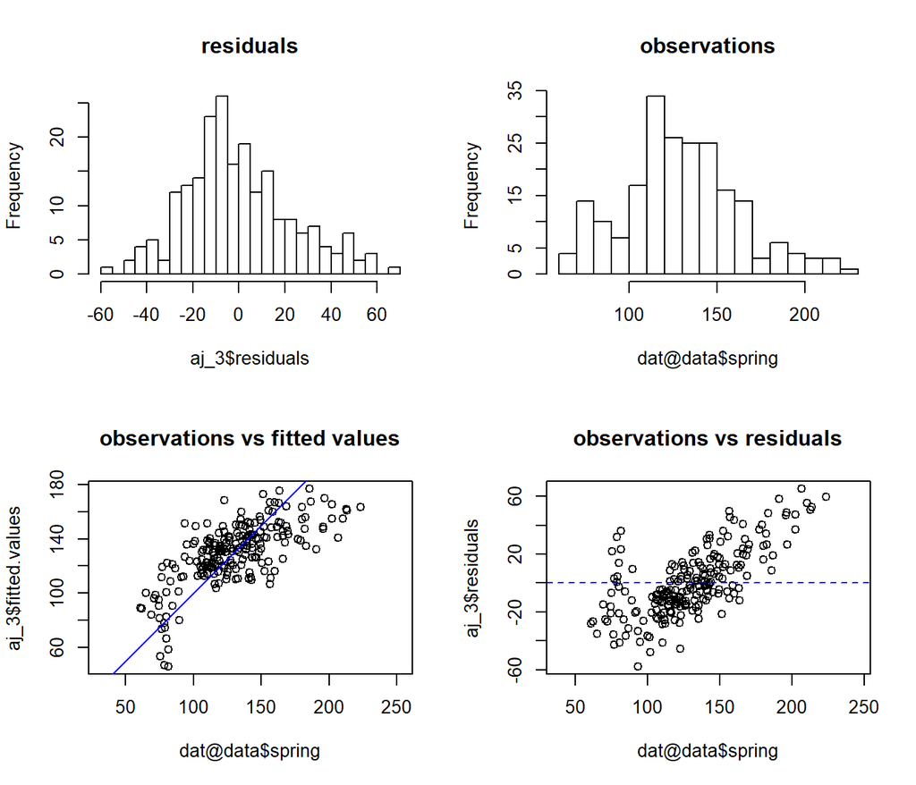

```r
par(mfrow=c(2,2))

hist(aj_3$residuals, breaks=20, main="residuals")   # Histogram of the fitted residuals
hist(dat@data$spring, breaks=20, main="observations")   # Histogram of the variable 'spring'

# Plot observations vs fitted values
plot(dat@data$spring, aj_3$fitted.values, asp=1, main="observations vs fitted values")
abline(a=0, b=1, col="blue", lty=1, lwd=1)

# Plot observations vs residuals
plot(dat@data$spring, aj_3$residuals, asp=1, main="observations vs residuals")
abline(h=0, col="blue", lty=2)
```

#### *Model 5*:

$$\begin{align}
& X^{autumn}_i \sim \mathcal{N}(\mu_i,\sigma^2), \hspace{15mm} i=1,\cdots,n \\
\\
&\mu_i = \beta_0 + \beta_1 \cdot X^{altitud}_i + \beta_2 \cdot X^{Xutm}_i + \beta_3 \cdot X^{Yutm}_i + \beta_4 \cdot X^{Xutm}_i \cdot X^{Yutm}_i.
\end{align}$$

Model adjustment.

Diagnosis plots.

```r
aj_4 <- lm( autumn ~ ALTITUD + dat@coords[,1]*dat@coords[,2] , data=dat@data )
summary(aj_4)
```

```
##
## Call:
## lm(formula = autumn ~ ALTITUD + dat@coords[, 1] * dat@coords[,
##     2], data = dat@data)
##
## Residuals:
##     Min      1Q  Median      3Q     Max
## -76.810 -17.844  -3.107  22.972  85.428
##
## Coefficients:
##                                   Estimate Std. Error t value Pr(>|t|)
## (Intercept)                     -2.133e+04  2.372e+03  -8.990  < 2e-16 ***
## ALTITUD                         -1.039e-02  9.834e-03  -1.057    0.292
## dat@coords[, 1]                  2.936e-02  3.303e-03   8.888 3.08e-16 ***
## dat@coords[, 2]                  4.778e-03  5.412e-04   8.828 4.54e-16 ***
## dat@coords[, 1]:dat@coords[, 2] -6.514e-09  7.526e-10  -8.656 1.38e-15 ***
## ---
## Signif. codes:  0 '***' 0.001 '**' 0.01 '*' 0.05 '.' 0.1 ' ' 1
##
## Residual standard error: 33.62 on 207 degrees of freedom
## Multiple R-squared:  0.5801, Adjusted R-squared:  0.572
## F-statistic: 71.49 on 4 and 207 DF,  p-value: < 2.2e-16
```

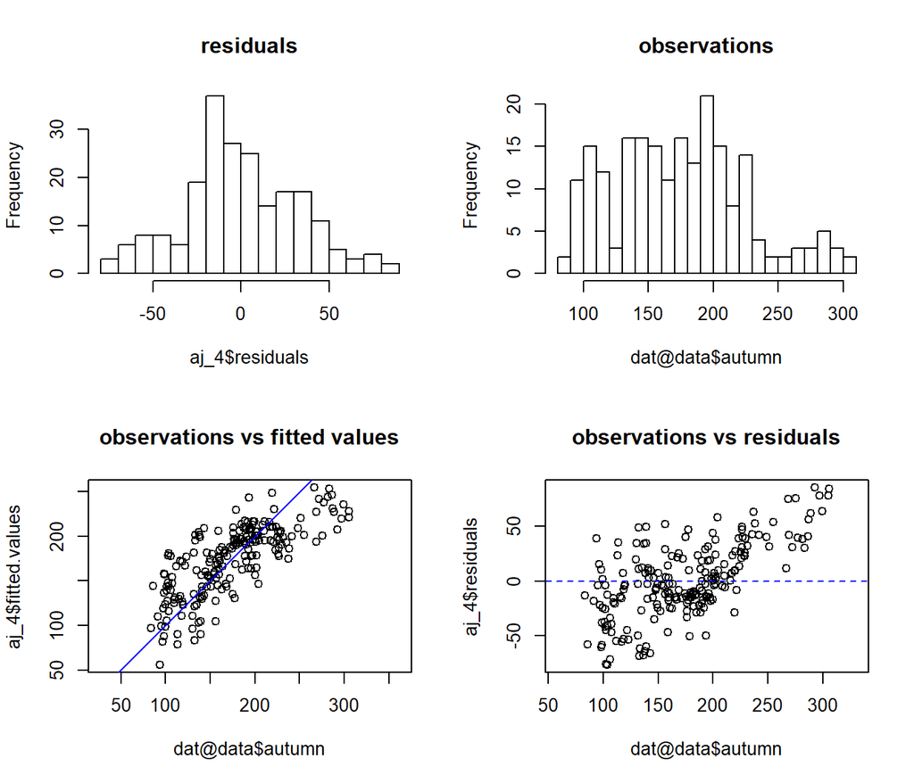

```r
par(mfrow=c(2,2))

hist(aj_4$residuals, breaks=20, main="residuals")   # Histogram of the fitted residuals
hist(dat@data$autumn, breaks=20, main="observations")   # Histogram of the variable 'autumn'

# Plot observations vs fitted values
plot(dat@data$autumn, aj_4$fitted.values, asp=1, main="observations vs fitted values")
abline(a=0, b=1, col="blue", lty=1, lwd=1)

# Plot observations vs residuals
plot(dat@data$autumn, aj_4$residuals, asp=1, main="observations vs residuals")
abline(h=0, col="blue", lty=2)
```

#### *Model 6*:

$$\begin{align}
& X^{winter}_i \sim \mathcal{N}(\mu_i,\sigma^2), \hspace{15mm} i=1,\cdots,n \\
\\
&\mu_i = \beta_0 + \beta_1 \cdot X^{altitud}_i + \beta_2 \cdot X^{Xutm}_i + \beta_3 \cdot X^{Yutm}_i + \beta_4 \cdot X^{Xutm}_i \cdot X^{Yutm}_i.
\end{align}$$

Model adjustment.

Diagnosis plots.

```r
aj_5 <- lm( winter ~ ALTITUD + dat@coords[,1]*dat@coords[,2] , data=dat@data )
summary(aj_5)
```

```
##
## Call:
## lm(formula = winter ~ ALTITUD + dat@coords[, 1] * dat@coords[,
##     2], data = dat@data)
##
## Residuals:
##     Min      1Q  Median      3Q     Max
## -83.012 -23.849  -5.022  20.916  94.283
##
## Coefficients:
##                                   Estimate Std. Error t value Pr(>|t|)
## (Intercept)                     -2.228e+04  2.557e+03  -8.715 9.42e-16 ***
## ALTITUD                          2.298e-02  1.060e-02   2.168   0.0313 *
## dat@coords[, 1]                  3.186e-02  3.560e-03   8.948  < 2e-16 ***
## dat@coords[, 2]                  5.003e-03  5.833e-04   8.576 2.30e-15 ***
## dat@coords[, 1]:dat@coords[, 2] -7.116e-09  8.111e-10  -8.773 6.50e-16 ***
## ---
## Signif. codes:  0 '***' 0.001 '**' 0.01 '*' 0.05 '.' 0.1 ' ' 1
##
## Residual standard error: 36.24 on 207 degrees of freedom
## Multiple R-squared:  0.392,  Adjusted R-squared:  0.3803
## F-statistic: 33.37 on 4 and 207 DF,  p-value: < 2.2e-16
```

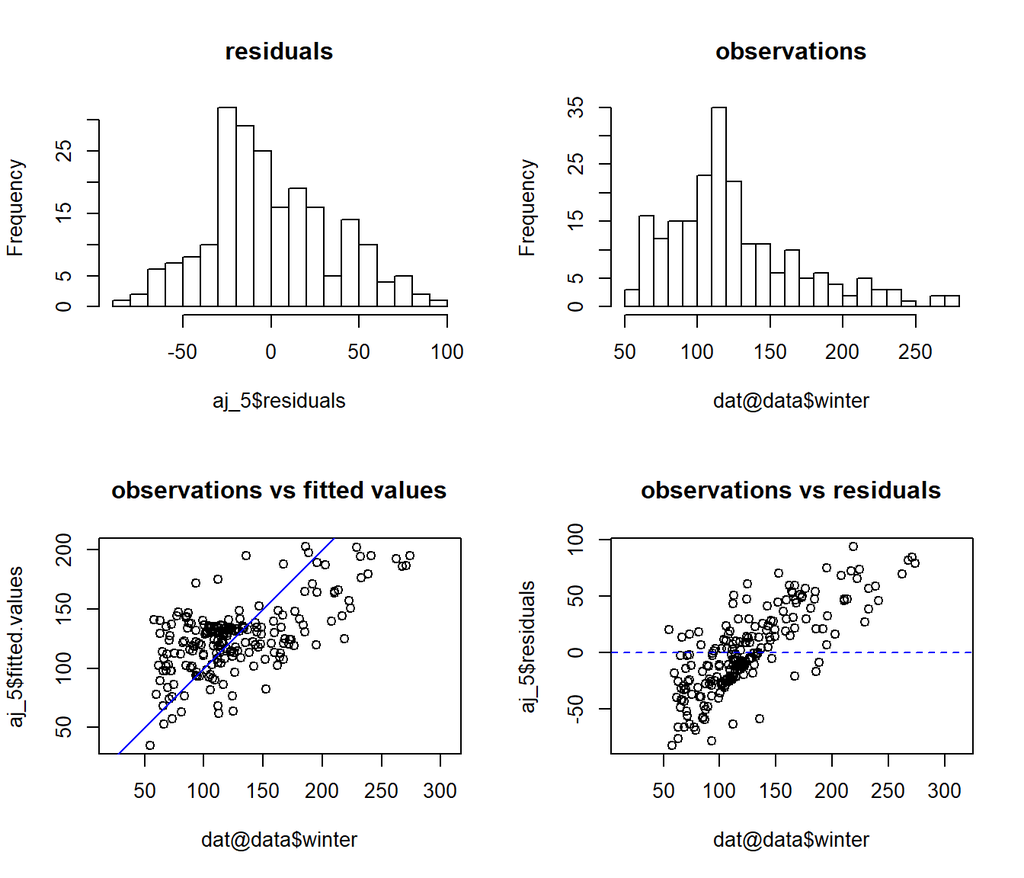

```r
par(mfrow=c(2,2))

hist(aj_5$residuals, breaks=20, main="residuals")   # Histogram of the fitted residuals
hist(dat@data$winter, breaks=20, main="observations")   # Histogram of the variable 'winter'

# Plot observations vs fitted values
plot(dat@data$winter, aj_5$fitted.values, asp=1, main="observations vs fitted values")
abline(a=0, b=1, col="blue", lty=1, lwd=1)

# Plot observations vs residuals
plot(dat@data$winter, aj_5$residuals, asp=1, main="observations vs residuals")
abline(h=0, col="blue", lty=2)
```

#### *Model 7*:

$$\begin{align}
& X^{summer}_i \sim \mathcal{N}(\mu_i,\sigma^2), \hspace{15mm} i=1,\cdots,n \\
\\
&\mu_i = \beta_0 + \beta_1 \cdot X^{altitud}_i + \beta_2 \cdot X^{Xutm}_i + \beta_3 \cdot X^{Yutm}_i + \beta_4 \cdot X^{Xutm}_i \cdot X^{Yutm}_i.
\end{align}$$

Model adjustment.

Diagnosis plots.

```r
aj_6 <- lm( summer ~ ALTITUD + dat@coords[,1]*dat@coords[,2] , data=dat@data )
summary(aj_6)
```

```
##
## Call:
## lm(formula = summer ~ ALTITUD + dat@coords[, 1] * dat@coords[,
##     2], data = dat@data)
##
## Residuals:
##     Min      1Q  Median      3Q     Max
## -53.386  -6.918  -0.899   6.312  26.952
##
## Coefficients:
##                                   Estimate Std. Error t value Pr(>|t|)
## (Intercept)                     -2.940e+03  7.428e+02  -3.958 0.000104 ***
## ALTITUD                          3.611e-02  3.079e-03  11.727  < 2e-16 ***
## dat@coords[, 1]                  3.020e-03  1.034e-03   2.920 0.003894 **
## dat@coords[, 2]                  6.696e-04  1.695e-04   3.951 0.000107 ***
## dat@coords[, 1]:dat@coords[, 2] -6.690e-10  2.357e-10  -2.839 0.004978 **
## ---
## Signif. codes:  0 '***' 0.001 '**' 0.01 '*' 0.05 '.' 0.1 ' ' 1
##
## Residual standard error: 10.53 on 207 degrees of freedom
## Multiple R-squared:  0.8453, Adjusted R-squared:  0.8423
## F-statistic: 282.8 on 4 and 207 DF,  p-value: < 2.2e-16
```

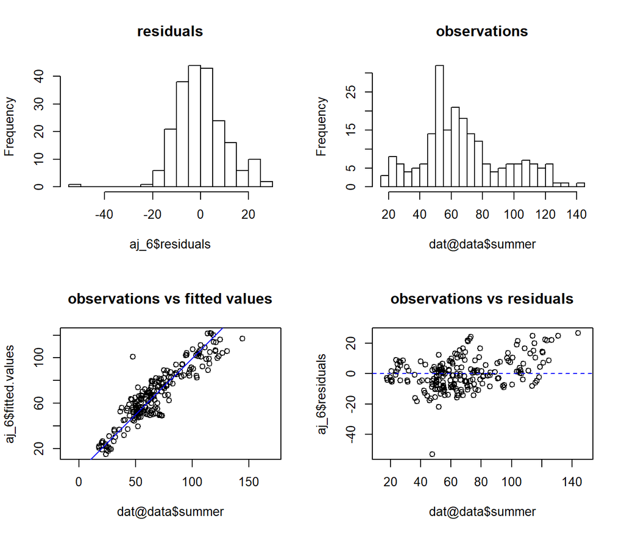

```r
par(mfrow=c(2,2))

hist(aj_6$residuals, breaks=20, main="residuals")   # Histogram of the fitted residuals
hist(dat@data$summer, breaks=20, main="observations")   # Histogram of the variable 'summer'

# Plot observations vs fitted values
plot(dat@data$summer, aj_6$fitted.values, asp=1, main="observations vs fitted values")
abline(a=0, b=1, col="blue", lty=1, lwd=1)

# Plot observations vs residuals
plot(dat@data$summer, aj_6$residuals, asp=1, main="observations vs residuals")
abline(h=0, col="blue", lty=2)
```